# Empfohlene Massnahmen zur Reduktion von Flugreisen an der Eawag

Bericht zuhanden der Direktion

Interessengruppe FlyAware

2019-12-10

English version

# Ein Aufruf zum Handeln

> „Es kommt nun darauf an, die Netto-Emissionen von CO2 und anderen Treibhausgasen schnell zu senken und weltweit spätestens zwischen 2040 und 2050 auf null zu reduzieren.“

Diese Stellungnahme der „Scientists for Future“ -Initiative wurde von 44 der 87 (50.6%) der Eawag-GruppenleiterInnen und AbteilungsleiterInnen unterzeichnet, darunter die Direktorin der Eawag sowie ihr Stellvertreter. Somit stimmt die Mehrheit der Eawag-Führungskräfte dieser Stellungnahme zu und ist sich der Dringlichkeit bewusst, dass Massnahmen ergriffen werden müssen, um die Treibhausgasemissionen zu reduzieren.

https://www.scientists4future.org/statement-en-und-es/

Einer der wirksamsten Wege für wissenschaftliche Forschungseinrichtungen die Klimaauswirkungen ihres Handelns zu reduzieren, ist Geschäftsflüge drastisch einzuschränken. Mehr als die Hälfte der Treibhausgasemissionen der ETH Zürich, der Schwesterinstitution der Eawag, wird durch Geschäftsreisen verursacht. Davon gehen 93% auf Flugreisen zurück. Mit technischen Alternativen, die die Treibhausgasemissionen von Flugzeugen wesentlich reduzieren, ist in absehbarer Zeit nicht zu rechnen. Folglich ist es dringend notwendig, die Anzahl der Flugreisen zu reduzieren.

https://ethz.ch/flugreisen

Die Eawag ist ein weltweit hochangesehenes Forschungsinstitut und hat die Möglichkeit als Vorbild für andere Forschungsinstitute zu agieren, indem sie ihre institutionelle Verantwortung wahrnimmt, die CO2-Emissionen weiter zu reduzieren. Genau jetzt ist die Zeit ein Vorbild zu sein – Hochschulen sowie die breite Öffentlichkeit werden sich endlich der enormen Auswirkungen von Flugreisen bewusst.

Bezüglich oft gestellter Fragen und einer frühen, breiten Petition von Wissenschaftlern aus der ganzen Welt im Jahr 2015 siehe: https://academicflyingblog.wordpress.com/

Dieser Bericht ist eine Aufforderung an die Eawag-Führungskräfte zu handeln. Wir haben neun konkrete Massnahmenpakete ausgearbeitet, wie die Eawag ihre aufgrund von Flugreisen verursachten CO2-Emissionen reduzieren kann. Um die Entscheidungsfindung zu unterstützen, stellen wir eine Liste mit zehn hochgradig akzeptierten und wirksamen Massnahmen zur Verfügung, die vorrangig umgesetzt werden sollen.

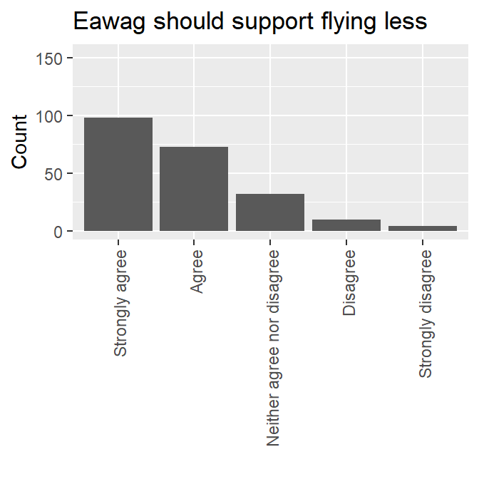

Die überwiegende Mehrheit der Eawag-Mitarbeitenden wünscht sich mehr Unterstützung von Seiten der Eawag, um Geschäftsflüge zu vermeiden.

Wir haben eine Umfrage unter den Eawag-Mitarbeitenden durchgeführt, an der ungefähr die Hälfte aller Eawag-Mitarbeitenden (232) teilgenommen hat. Die Eawag-Mitarbeitenden wurden dazu aufgerufen, die in diesem Bericht vorgestellten Massnahmen zu bewerten. Aufgrund der hohen Teilnehmeranzahl repräsentieren die Ergebnisse dieser Umfrage mit hoher Wahrscheinlichkeit die Sichtweise der Eawag-Mitarbeitenden hinsichtlich der Thematik Fliegen sowie hinsichtlich der vorgeschlagenen Massnahmen.

Der vom Menschen verursachte Klimawandel und die daraus resultierenden Gefahren sind umfassend wissenschaftlich belegt. Darum fordern wir Euch als (Umwelt-)Wissenschaftler und Direktionsmitglieder dazu auf, die Lücke zwischen Wissen und Handeln zu überwinden und einen Wandel an der Eawag herbeizuführen.

## Welche Massnahmen soll die Eawag umsetzen?

Wir schlagen vor, die folgenden Massnahmen umgehend umzusetzen:

Der vollständige Massnahmenkatalog, der den Eawag-Mitarbeitenden zur Abstimmung vorgelegt wurde, kann hier heruntergeladen werden.

**Offizielle Erklärung (Eawag Richtlinie)**

Die Eawag schreibt offiziell fest, dass Transportoptionen mit niedrigem CO2-Ausstoss (bspw. Zugreisen) gegenüber Transportoptionen mit hohem CO2-Ausstoss (bspw. Flugreisen) vorzuziehen sind.

**Intranet-Seite**

Die Eawag erstellt eine Intranet-Seite zum Thema klimafreundliche Mobilität. Diese Website stellt Informationen zur Verfügung hinsichtlich:

1. Internationale Zugreisen, insbesondere zu Buchungsplattformen (bspw. Loco2.com, trainline.com, interrail.eu), welche den Kauf von Zugtickets in Europa vereinfachen
2. Weiterbildungen für das Abhalten von Videokonferenzen (siehe Massnahme «Förderung von Videokonferenzen»)
3. CO2-Kompensation von Flugreisen an der Eawag

**Förderung von Videokonferenzen**

Die Eawag regt zur Benutzung der Technologie an, indem sie Videokonferenzen an grösseren Veranstaltungen anwendet und hervorhebt, bspw. an Eawag-Seminaren und bei durch die Eawag organisierten Konferenzen.

**Zugreisen als offizielle Richtlinie**

Die Eawag schreibt offiziell fest (siehe Massnahme «Offizielle Erklärung»), dass Flüge vermieden werden sollen, wenn das Reiseziel innerhalb 10 Stunden per Zug oder über Nacht per Nachtzug erreicht werden kann. Die Anreise wird als Arbeitszeit gewertet.

**Übernahme von Zusatzkosten verursacht durch Zugreisen**

Durch Zugreisen entstehende Zusatzkosten im Vergleich zu Flugreisen (bspw. höhere Ticketkosten oder Zusatzübernachtungen), werden von der Eawag übernommen. Dies geschieht beispielsweise durch Finanzmittel, welche durch erhöhte Kompensationszahlungen auf Flugreisen gewonnen werden (siehe Massnahme «Verdopplung der CO2-Kompensation»).

**Kompensation aller Flugreisen**

Alle Flüge, unabhängig davon worüber sie finanziert sind, werden im jährlichen Eawag Reporting gelistet (siehe Massnahme «Verbesserte Datengrundlage»). Dies führt dazu, dass auch durch externe Mittel (z.B. Einladungen von anderen Forschungseinrichtungen) bezahlte Flugreisen kompensiert werden können, die bisher unter den Radar gefallen sind.

**Verdopplung der CO2-Kompensation**

Um klimafreundliche Mobilität weiter zu fördern, wird die CO2-Kompensation pro Flug verdoppelt.

**Interne Reduktionsziele**

Nach drei Jahren Datenerhebung (siehe Massnahme «Verbesserte Datengrundlage») sind Abteilungen verpflichtet, sich interne Reduktionsziele zu setzen. Dies kann beispielsweise eine Reduktion um 20% bis 50% sein im Verlaufe der folgenden fünf Jahre verglichen mit dem Durchschnitt der vorhergehenden drei Jahre.

**Verbesserte Datengrundlage**

Im jährlichen Reporting der Eawag werden bereits jetzt Daten zu Konferenzbeiträgen, Betreuung von Studierenden usw. gesammelt. Diese Daten werden mit Angaben zum Mobilitätsverhalten erweitert. Dabei werden für jede internationale Dienstreise folgende Informationen erhoben:

1. Art des Transportmittels
2. Grund der Reise (Konferenz, Projektsitzung, usw.)
3. Abreise- und Ankunftsort

Einer der wirksamsten Wege Treibhausgasemissionen verursacht durch Flugreisen zu reduzieren, ist die Beschränkung von Langstreckenflügen. Deshalb empfehlen wir nachdrücklich eine Massnahme miteinzubeziehen, die sich auf Langstreckenflüge auswirkt:

siehe bspw. Jäckle, S. Eur Polit Sci (2019) 18: 630. https://doi.org/10.1057/s41304-019-00220-6

**Reduktion von Langstreckenflügen**

Langstreckenflüge (interkontinentale Flüge) tragen mit Abstand am stärksten zu den durch Flugreisen entstehenden CO2-Emissionen der Eawag bei. Die Eawag schränkt daher die Zahl solcher Flüge ein (ausser für Feldarbeit).

1. Gruppenleiter, Abteilungsleiter und Direktorat: maximal 1 Langstreckenflug innerhalb von zwei Jahren
2. Doktoranden und Postdocs: maximal 1 Langstreckenflug innerhalb des Doktorats bzw. Projektdauer des Postdocs
3. Restliche Angestellte: maximal 1 Langstreckenflug innerhalb von 4 Jahren (vergleichbar mit der durchschnittlichen Dauer eines Doktorats)

## Auswahl von Massnahmen zur Umsetzung

Um die Massnahmen auszuwählen, die umgehend umgesetzt werden sollen, haben wir diese hinsichtlich ihrer Akzeptanz unter den Eawag-Mitarbeitenden, hinsichtlich ihrer zu erwartenden Auswirkung auf die Reduktion von Treibhausgasemissionen sowie hinsichtlich des zu erwartenden Aufwands (finanzielle Kosten und Arbeitszeit) klassifiziert. Die Akzeptanz der Massnahmen wurde in drei Gruppen aufgeteilt. Diese Einteilung beruht für jede Massnahme auf der Verteilung der Zustimmung unter den Eawag-Mitarbeitenden. Eine Übersicht aller Verteilungen kann hier heruntergeladen werden. Umfrageteilnehmer hatten die Möglichkeit, qualitative Kommentare zu den einzelnen Massnahmen hinzuzufügen. Eine Zusammenfassung dieser Kommentare hinsichtlich ausgewählter Massnahmen ist hier verfügbar. Die zu erwartenden Auswirkungen und Kosten basieren auf Beurteilungen der FlyAware-Mitglieder und stellen somit nur eine vorläufige Einschätzung dar. Wir begrüssen einen weiteren Austausch hinsichtlich der Priorisierung der Massnahmen.

Allerdings muss berücksichtigt werden, dass keine einzige Massnahme mehrheitlich von den Umfrageteilnehmenden abgelehnt wurde.

Die Umfrageergebnisse können unter folgendem Link interaktiv erkundet werden: https://marioangst.shinyapps.io/flyaware_survey/ Informationen zur Auswertung der Umfrage sind unter folgendem Link verfügbar: https://github.com/marioangst/flyaware_survey

Wir empfehlen, die Massnahmen in vier Gruppen einzuteilen:

- Hohe Zustimmung: Diese Massnahmen werden von einer breiten Mehrheit der Eawag-Mitarbeitenden unterstützt. Sie verursachen überwiegend einen geringen (Kosten-)Aufwand (Zeit, Geld,..) bei der Umsetzung. Wir empfehlen, diese sofort umzusetzen.
- Sehr umstritten, hochwirksam: Diese Massnahmen sind sehr umstritten jedoch hochwirksam. Wir empfehlen diese Massnahmen für den Moment zurückzustellen, mit Ausnahme der Massnahme, die sich für die Reduktion der Langstreckenflüge einsetzt. Diese Massnahme hat die grösste Wirkung und keine andere Massnahme wirkt sich direkt auf Langstreckenflüge aus.
- Umstritten, mittlere Wirksamkeit: Leicht umstrittene, mittelwirksame Massnahmen. Wir empfehlen die Umsetzung dieser Massnahmen.
- Umstritten, geringe Wirksamkeit: Leicht umstrittene Massnahmen mit relativ geringerer Wirksamkeit. Wir empfehlen diese Massnahmen für den Moment zurückzustellen, mit der Ausnahme, das bestehende Reporting der Eawag hinsichtlich des Mobilitätsverhaltens zu erweitern, da es die Grundlage für weitere Massnahmen bildet.

Kategorisierung der Massnahmen basierend auf Akzeptanz, erwarteter Wirkung, und erwarteten Kosten. Jeder Kreis repräsentiert eine Massnahme, dessen Grösse die erwarteten Kosten der Massnahme.

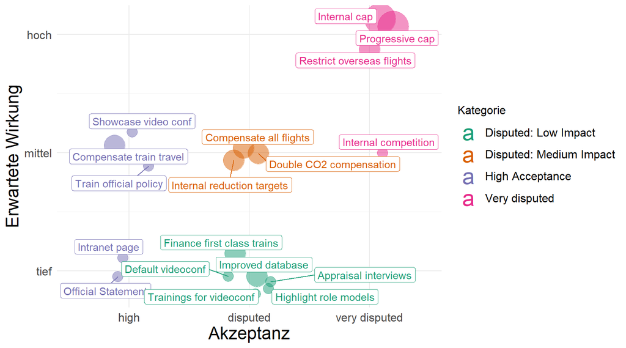

## Vollständiger vorgeschlagener Massnahmenkatalog

Der vollständige Massnahmenkatalog, welcher den Eawag-Mitarbeitenden zur Beurteilung innerhalb der FlyAware-Umfrage vorgeschlagen wurde, kann hier heruntergeladen werden. Dieser Katalog wurde zuerst innerhalb des Kernteams und anschliessend innerhalb der erweiterten FlyAware-Gruppe ausgearbeitet. Dazu wurden auch Initiativen anderer Institutionen, wie z.B. der ETH und der EPFL, berücksichtigt. Wir haben versucht, eine Kombination aus regulatorischen, anreizstiftenden sowie informationalen Massnahmen zusammenzustellen.

## Mitglieder des Kernteams FlyAware

- Mario Angst, Eawag ESS
- Andri Brugger, Université de Neuchâtel (vorher ESS)
- Jonas Heiberg, Eawag ESS
- Karin Kiefer, Eawag UCHEM
- Andrea Rösch, Agroscope (vorher UCHEM)
- Philipp Staudacher, Eawag UCHEM